# Preprocessing: Imputation of missing education values

Michael Lindner

6/10/2022

# Preliminaries: Version control

For exact reproducibility of our results we use the package manager `renv` to keep track of the versions of all packages used.

To reproduce our analysis, install `renv` then use `renv::activate()` to activate the environment specified in the lockfile. You might have to use `renv::hydrate()` to install required packages as well. Afterwards you can run the R code as you would normally do.

Troubleshooting: `renv::restore()`

# Load librariers and data set

We begin by loading libraries…

```r
library("haven")
library("dplyr")
library(tidyr)
library(labelled)
library(mice)
```

This time we need data from several of the lcf data sets

```r
lcf <- read_sav("../data/lcf.sav")
rawper <- read_sav("../data/raw/2018_rawper_ukanon_final.sav")
weekly_ghg_hh <- read_sav("../data/weekly_ghg_hh.sav")
```

Join GHG to expenditure data

```r
lcf <- full_join(lcf, weekly_ghg_hh, by="case")
```

Set random seed for reproducibility

```r
set.seed(123)
```

## Highest education per household

```r
# Check number of NAs in individual dataset (40.1% missing)
sum(is.na(rawper$HighEd1))
```

```
## [1] 5116
```

```r
# Introduce a new factor level for people that are in Education (School)
rawper$HighEd1[!is.na(rawper$School)] <- 9
# Introduce a new factor level for people that are in Education (University)
rawper$HighEd1[rawper$TypeEd == 5] <- 10

# Check number of NAs again
is.na(rawper$HighEd1) %>% sum
```

```
## [1] 2588
```

```r
rawall <- full_join(rawper, lcf, by = "case")
```

## MICE

Summarize ethnicity variable

```r
rawall$Ethp <- rawall$EthEp
rawall$Ethp[!is.na(rawall$EthNIp)] <- rawall$EthNIp[!is.na(rawall$EthNIp)]
rawall$Ethp[!is.na(rawall$EthSp)] <- rawall$EthSp[!is.na(rawall$EthSp)]
rawall$Ethp[!is.na(rawall$EthWp)] <- rawall$EthWp[!is.na(rawall$EthWp)]
```

We arrive at the predictors for predictive mean matching (PMM) via the following strategy: * Select from literature (income, sex, ethnicity, geography)

```r
pred_literature <- c("Ten1",
                     "Sex",
                     "Gorx",
                     "A094", # socio economic status of HRP
                     "EcStatus", # socio economic status
                     "Ethp", # ethnicity
                     "EqIncDOp", # household inc
                     "GWkIncp", # personal income
                     "a111p", # rooms
                     "G018", # adults
                     #"G019", # children
                     "a070p" # age of oldest person in HH
                     #"a065p", # age of HRP
                     #"DVAge18" # age of person
                     )
```

- Test the quality of the linear model and remove insignificant predictors

```r
dfimp <- rawall %>% select(case,HighEd1,pred_literature)
```

```
## Note: Using an external vector in selections is ambiguous.
## ℹ Use `all_of(pred_literature)` instead of `pred_literature` to silence this message.
## ℹ See <https://tidyselect.r-lib.org/reference/faq-external-vector.html>.
```

```r
dfimp[,2:8] <- lapply(dfimp[,2:8] %>% zap_labels, as_factor)
dfimp[,9:ncol(dfimp)] <- dfimp[,9:ncol(dfimp)] %>% zap_labels


# Test the quality of the linear model
L <- glm(HighEd1 ~ ., dfimp[,2:ncol(dfimp)], family = binomial())
summary(L)
```

```
##
## Call:
## glm(formula = HighEd1 ~ ., family = binomial(), data = dfimp[,
##     2:ncol(dfimp)])
##
## Deviance Residuals:
##     Min       1Q   Median       3Q      Max
## -2.9512  -0.9353   0.4749   0.8232   2.6834
##
## Coefficients:
##               Estimate Std. Error z value Pr(>|z|)
## (Intercept)  2.449e-01  2.795e-01   0.876 0.380997
## Ten12        2.204e-01  8.028e-02   2.746 0.006041 **
## Ten13        4.373e-02  4.790e-01   0.091 0.927262
## Ten14        4.127e-01  9.856e-02   4.187 2.82e-05 ***
## Ten15        1.286e-01  3.340e-01   0.385 0.700298
## Sex2        -3.824e-01  5.978e-02  -6.397 1.59e-10 ***
## Gorx2       -5.884e-01  1.736e-01  -3.390 0.000698 ***
## Gorx3       -4.081e-02  1.829e-01  -0.223 0.823484
## Gorx4       -5.020e-02  1.847e-01  -0.272 0.785825
## Gorx5       -3.311e-01  1.815e-01  -1.824 0.068145 .
## Gorx6       -1.002e-01  1.785e-01  -0.562 0.574426
## Gorx7       -8.656e-01  1.796e-01  -4.821 1.43e-06 ***
## Gorx8       -3.119e-01  1.715e-01  -1.819 0.068976 .
## Gorx9       -6.147e-01  1.748e-01  -3.516 0.000438 ***
## Gorx10      -4.154e-01  2.035e-01  -2.041 0.041283 *
## Gorx11      -4.866e-01  1.691e-01  -2.877 0.004012 **
## Gorx12      -3.847e-01  1.880e-01  -2.046 0.040733 *
## A0942       -3.765e-01  1.267e-01  -2.971 0.002966 **
## A0943        7.595e-02  1.197e-01   0.635 0.525661
## A0944        7.231e-01  1.457e-01   4.962 6.99e-07 ***
## A0945        7.649e-01  1.611e-01   4.747 2.06e-06 ***
## A0946        1.339e+00  1.606e-01   8.340  < 2e-16 ***
## A0947        1.596e+00  1.673e-01   9.540  < 2e-16 ***
## A0948        1.384e+00  1.819e-01   7.607 2.80e-14 ***
## A0949        4.254e-01  3.423e-01   1.243 0.213967
## A09410       1.578e+00  3.025e-01   5.216 1.83e-07 ***
## A09411       4.566e-01  4.695e-01   0.973 0.330739
## A09412       4.192e-01  1.566e-01   2.677 0.007428 **
## EcStatus2    3.286e-01  8.523e-02   3.855 0.000116 ***
```

[output cut: 13 more lines]

```
## GWkIncp     -2.239e-04  8.501e-05  -2.634 0.008433 **
## a111p       -1.077e-01  1.916e-02  -5.622 1.89e-08 ***
## G018         2.125e-01  3.874e-02   5.484 4.16e-08 ***
## a070p        2.521e-02  2.980e-03   8.459  < 2e-16 ***
## ---
## Signif. codes:  0 '***' 0.001 '**' 0.01 '*' 0.05 '.' 0.1 ' ' 1
##
## (Dispersion parameter for binomial family taken to be 1)
##
##     Null deviance: 9738.4  on 7647  degrees of freedom
## Residual deviance: 7881.4  on 7602  degrees of freedom
##   (5115 observations deleted due to missingness)
## AIC: 7973.4
##
## Number of Fisher Scoring iterations: 5
```

```r
#library(jtools)
#summ(L)
```

We impute the missing values with predictive mean matching and study the plausibility and convergence of the generated imputations.

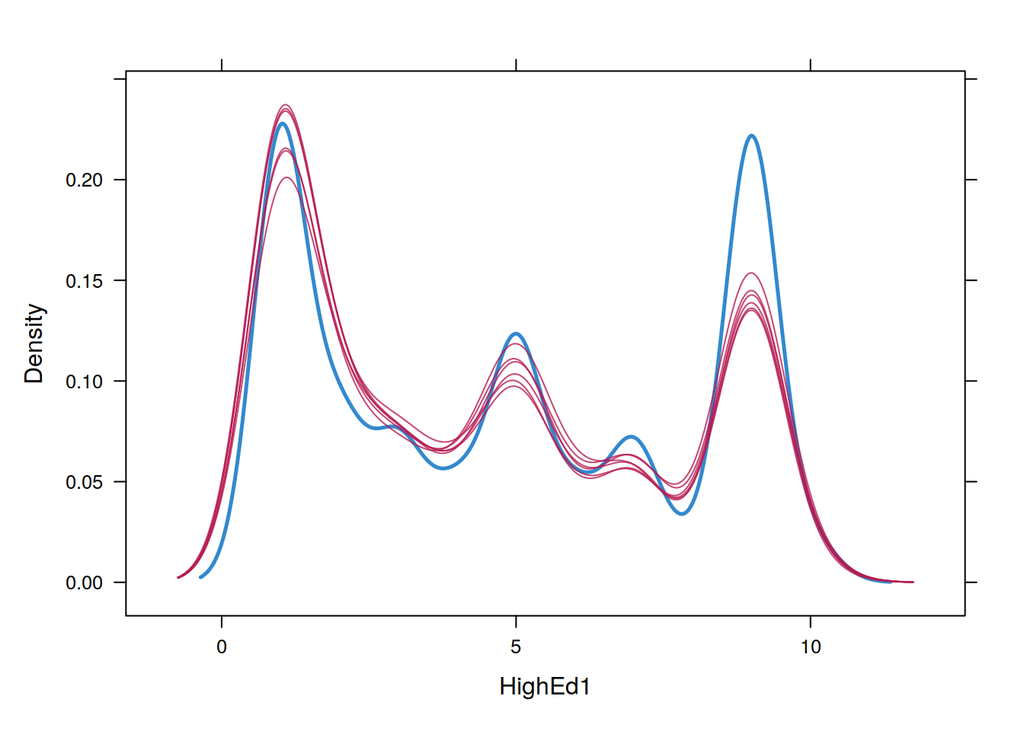

```r
imp <- mice(dfimp,  m = 6, method = "pmm", print=FALSE, maxit=10)
densityplot(imp, ~HighEd1)
```

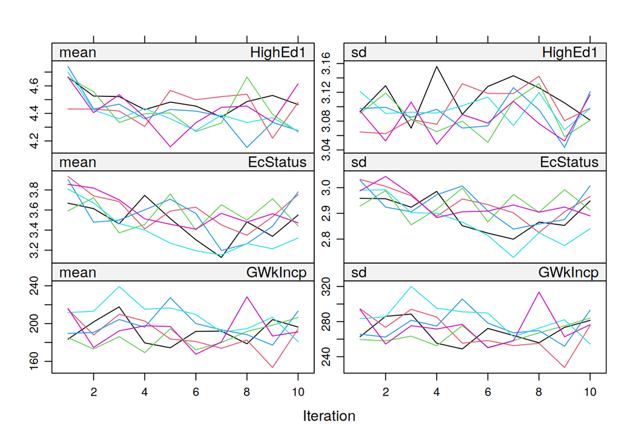

```r
plot(imp)
```

Join with lcf data

```r
iml <- complete(imp, "all", include=TRUE)

mil <- lapply(iml, function(x) x %>% select(case, HighEd1) %>%  group_by(case) %>%
  slice_min(order_by = HighEd1, with_ties=FALSE) %>%
  rename(HighEdHH = HighEd1) %>% full_join(lcf, by = "case"))
```

And save

```r
if (FALSE) {
saveRDS(mil, file="../data/lcf_milper.rds")
}
```